# Echoes of Loss - Impact Assessment

# Does “Echoes of Loss” improve visitors’ care?

We want to verify whether there is a significant increase of heritage care intentions and perceived efficacy. We upload the pre- and post-survey datasets and pre-process the data (rename columns) before running the full validation.

```r
library(tidyverse)
library(dplyr)
library(readxl)
library(purrr)
library(stats)


source_pre_df <- read_xlsx("source_data/Care01-Pre.xlsx")
source_post_df <- read_xlsx("source_data/Care02-Post.xlsx")

# ------------------------------------------
# STEP 0. Create a sub-df and rename columns
# ------------------------------------------

intention_post <- source_post_df[, c(1, 26:32)]

intention_pre <- source_pre_df[, c(1, 30:36)] %>%
  filter(`Pseudo-ID` %in% intention_post$`Pseudo-ID`) %>%
  arrange(match(`Pseudo-ID`, intention_post$`Pseudo-ID`))

names(intention_pre)[names(intention_pre) == "In this moment, I would love to discuss with friends or family about topics connected to cultural heritage"] <- "Discuss CH"
names(intention_post)[names(intention_post) == "In this moment, I would love to discuss with friends or family about topics connected to cultural heritage"] <- "Discuss CH"

names(intention_pre)[names(intention_pre) == "In this moment, I would like to learn more about a collection I visited"] <- "Learn more"
names(intention_post)[names(intention_post) == "In this moment, I would like to learn more about a collection I visited"] <- "Learn more"

names(intention_pre)[names(intention_pre) == "In this moment, I would like to support  research and activties in the cultural domain (e.g. volunteering, donations)"] <- "Support research"
names(intention_post)[names(intention_post) == "In this moment, I would like to support  research and activties in the cultural domain (e.g. volunteering, donations)"] <- "Support research"

names(intention_pre)[names(intention_pre) == "I believe that citizens, as a group, can take care of cultural heritage"] <- "Collective efficacy"
names(intention_post)[names(intention_post) == "I believe that citizens, as a group, can take care of cultural heritage"] <- "Collective efficacy"

names(intention_pre)[names(intention_pre) == "I believe that I, through individual actions, can take care of cultural heritage"] <- "Individual efficacy"
names(intention_post)[names(intention_post) == "I believe that I, through individual actions, can take care of cultural heritage"] <- "Individual efficacy"

names(intention_pre)[names(intention_pre) == "I believe that I, as an individual, can provide an important  contribution so that citizens,together, can take care of cultural  heritage"] <- "Participative efficacy"
names(intention_post)[names(intention_post) == "I believe that I, as an individual, can provide an important contribution so that citizens,together, can take care of cultural heritage"] <- "Participative efficacy"

names(intention_pre)[names(intention_pre) == "In the last year, I supported or endorsed cultural events or similar initiatives"] <- "General support"
names(intention_post)[names(intention_post) == "In the future, I will support or endorse cultural events or similar initiatives"] <- "General support"
```

After importing the data, renaming the columns and selecting only common IDs to the two datasets, we proceed converting Likert string labels into numeric values.

```r
# ------------------------------------------
# STEP 1. Convert Likert into nnumeric vals
# ------------------------------------------

convert_likert <- function(df) {
  df_converted <- df

  # Dizionario Likert in lowercase
  lik_lower <- c(
    "strongly disagree" = 1,
    "disagree"          = 2,
    "neutral"           = 3,
    "agree"             = 4,
    "strongly agree"    = 5
  )

  for (c in names(df_converted)) {
    # Skip ID
    if (c %in% c("Pseudo-ID")) next

    # If factor: process text
    if (is.character(df_converted[[c]]) || is.factor(df_converted[[c]])) {

      # trim + lowercase + clean double spaces
      vals <- df_converted[[c]] |>
        as.character() |>
        trimws() |>
        tolower()

      # map to lowercase dict
      mapped <- lik_lower[vals]

      # cast to int
      df_converted[[c]] <- suppressWarnings(as.numeric(mapped))

    }
  }

  df_converted
}

# apply function to source dataset
intention_pre  <- convert_likert(intention_pre)
intention_post <- convert_likert(intention_post)

# all(intention_pre$ID == intention_post$ID) # proceed only if TRUE
```

We will run the analysis on the two distinct datasets “intention_pre” and “intention_post”. As an exploratory analysis, we firstly observe the tendency for each item of the questionnaire. We use box plots to observe the distribution of the answers

```r
library(ggpubr)

items <- c("Discuss CH", "Learn more", "Support research", "Collective efficacy", "Individual efficacy", "Participative efficacy", "General support")

# crea long format
long_data <- bind_rows(
  intention_pre  %>% mutate(time = "pre"),
  intention_post %>% mutate(time = "post")
) %>%
  pivot_longer(cols = all_of(items), names_to = "item", values_to = "value")

# calcola medie
means_data <- long_data %>%
  group_by(item, time) %>%
  summarise(mean_val = round(mean(value, na.rm = TRUE), 2), .groups = "drop")

print(means_data)
```

```
## # A tibble: 14 × 3
##    item                   time  mean_val
##    <chr>                  <chr>    <dbl>
##  1 Collective efficacy    post      4.26
##  2 Collective efficacy    pre       4.21
##  3 Discuss CH             post      4.03
##  4 Discuss CH             pre       3.9
##  5 General support        post      4.34
##  6 General support        pre       3.76
##  7 Individual efficacy    post      3.93
##  8 Individual efficacy    pre       3.7
##  9 Learn more             post      4.19
## 10 Learn more             pre       4.11
## 11 Participative efficacy post      4.14
## 12 Participative efficacy pre       3.99
## 13 Support research       post      3.77
## 14 Support research       pre       3.5
```

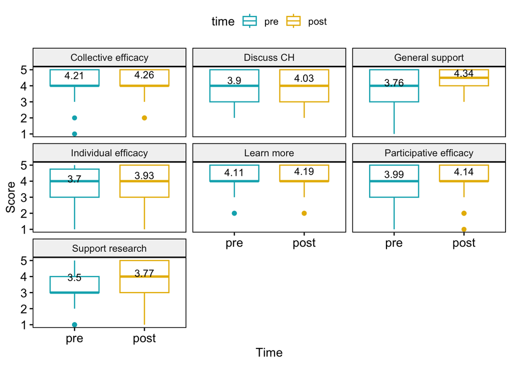

```r
ggboxplot(long_data, x = "time", y = "value",
          color = "time", palette = c("#00AFBB", "#E7B800"),
          order = c("pre", "post"),
          facet.by = "item",
          ylab = "Score", xlab = "Time") +
  stat_summary(fun = mean, geom = "text",
               aes(label = round(after_stat(y), 2), group = time),
               position = position_dodge(0.8),
               vjust = -0.5, size = 3.5, color = "black")
```

```r
library(rstatix)
library(purrr)
library(coin)
```

```r
map_dfr(items, ~ {
  d <- intention_pre[[.x]] - intention_post[[.x]]
  r <- wilcox_effsize(
    data      = data.frame(
      value = c(intention_pre[[.x]], intention_post[[.x]]),
      time  = rep(c("pre", "post"), each = nrow(intention_pre))
    ),
    formula   = value ~ time,
    paired    = TRUE
  )
  tibble(
    item    = .x,
    r_rb    = round(r$effsize, 3),
    W       = shapiro.test(d)$statistic,
    p_value = shapiro.test(d)$p.value
  )
})
```

| item | r_rb | W | p_value |
| --- | --- | --- | --- |
| Discuss CH | 0.185 | 0.8037921 | 3.019593e-08 |
| Learn more | 0.062 | 0.7898864 | 1.299224e-08 |
| Support research | 0.333 | 0.7412919 | 8.776214e-10 |
| Collective efficacy | 0.034 | 0.7541717 | 1.732224e-09 |
| Individual efficacy | 0.237 | 0.8163109 | 6.664483e-08 |
| Participative efficacy | 0.201 | 0.7891388 | 1.242882e-08 |
| General support | 0.440 | 0.9150418 | 1.606788e-04 |

As the normality assumption is not met, we proceed with a [**One-tail Paired Samples Wilcoxon Signed Rank Test**](https://www.sthda.com/english/wiki/one-sample-wilcoxon-signed-rank-test-in-r). We choose one-tail over two-tail, as we are interested only in verifying an improvement in the intentions.

```r
print("Discuss CH")
```

```
## [1] "Discuss CH"
```

```r
res_discuss <- wilcox.test(intention_post$`Discuss CH`, intention_pre$`Discuss CH`, paired = TRUE, alternative = "greater")
res_discuss
```

```
##
##  Wilcoxon signed rank test with continuity correction
##
## data:  intention_post$`Discuss CH` and intention_pre$`Discuss CH`
## V = 266, p-value = 0.0544
## alternative hypothesis: true location shift is greater than 0
```

```r
print("Learn more")
```

```
## [1] "Learn more"
```

```r
res_learn <- wilcox.test(intention_post$`Learn more`, intention_pre$`Learn more`, paired = TRUE, alternative = "greater")
res_learn
```

```
##
##  Wilcoxon signed rank test with continuity correction
##
## data:  intention_post$`Learn more` and intention_pre$`Learn more`
## V = 178, p-value = 0.2014
## alternative hypothesis: true location shift is greater than 0
```

```r
print("Support research")
```

```
## [1] "Support research"
```

```r
res_research <- wilcox.test(intention_post$`Support research`, intention_pre$`Support research`, paired = TRUE, alternative = "greater")
res_research
```

```
##
##  Wilcoxon signed rank test with continuity correction
##
## data:  intention_post$`Support research` and intention_pre$`Support research`
## V = 228.5, p-value = 0.001826
## alternative hypothesis: true location shift is greater than 0
```

```r
print("Collective efficacy")
```

```
## [1] "Collective efficacy"
```

```r
res_collective <- wilcox.test(intention_post$`Collective efficacy`, intention_pre$`Collective efficacy`, paired = TRUE, alternative = "greater")
res_collective
```

```
##
##  Wilcoxon signed rank test with continuity correction
##
## data:  intention_post$`Collective efficacy` and intention_pre$`Collective efficacy`
## V = 130.5, p-value = 0.295
## alternative hypothesis: true location shift is greater than 0
```

```r
print("Individual efficacy")
```

```
## [1] "Individual efficacy"
```

```r
res_individual <- wilcox.test(intention_post$`Individual efficacy`, intention_pre$`Individual efficacy`, paired = TRUE, alternative = "greater")
res_individual
```

```
##
##  Wilcoxon signed rank test with continuity correction
##
## data:  intention_post$`Individual efficacy` and intention_pre$`Individual efficacy`
## V = 291, p-value = 0.01781
## alternative hypothesis: true location shift is greater than 0
```

```r
print("Participative efficacy")
```

```
## [1] "Participative efficacy"
```

```r
res_participative <- wilcox.test(intention_post$`Participative efficacy`, intention_pre$`Participative efficacy`, paired = TRUE, alternative = "greater")
res_participative
```

```
##
##  Wilcoxon signed rank test with continuity correction
##
## data:  intention_post$`Participative efficacy` and intention_pre$`Participative efficacy`
## V = 208, p-value = 0.04009
## alternative hypothesis: true location shift is greater than 0
```

```r
print("General support")
```

```
## [1] "General support"
```

```r
res_support <- wilcox.test(intention_post$`General support`, intention_pre$`General support`, paired = TRUE, alternative = "greater")
res_support
```

```
##
##  Wilcoxon signed rank test with continuity correction
##
## data:  intention_post$`General support` and intention_pre$`General support`
## V = 748, p-value = 7.109e-05
## alternative hypothesis: true location shift is greater than 0
```

These analysis indeed confirm our first observations from the box plots. Nonetheless, as we are dealing with seven parallel hypothesis testings, we apply a Bonferroni - Holm correction:

```r
p_values <- c(
  discuss      = res_discuss$p.value,
  learn        = res_learn$p.value,
  research     = res_research$p.value,
  collective   = res_collective$p.value,
  individual   = res_individual$p.value,
  participative = res_participative$p.value,
  support      = res_support$p.value
)

p_adjusted <- p.adjust(p_values, method = "holm")
p_adjusted
```

```
##       discuss         learn      research    collective    individual
##  0.1631971668  0.4027059240  0.0109536983  0.4027059240  0.0890746568
## participative       support
##  0.1603507947  0.0004976371
```

As a result, we notice that only “Support Research” and “General Support” are statistically significant.

## Ceiling effect mitigation

However, we can further refine the analysis. We know that the sample is mainly composed by people with a strong background in the heritage domain, which can result into a ceiling effect. We mitigate this effect by dynamically changing the sample size of each hypothesis testing: we will consider only those who have *not* answered 5/5 in the pre-test, and we ensure that the resulting sample size is always greater than 36 (minimum sample size as per by GPower). We then reproduce the same tests as above.

```r
add_ceiling_correction <- function(df_a, df_b, colname) {
  ceiling_ids <- df_a$`Pseudo-ID`[df_a[[colname]] >= 5]

  pre_ids    <- df_a$`Pseudo-ID`[!df_a$`Pseudo-ID` %in% ceiling_ids]
  post_ids   <- df_b$`Pseudo-ID`[!df_b$`Pseudo-ID` %in% ceiling_ids]
  common_ids <- intersect(pre_ids, post_ids)

  pre  <- df_a[[colname]][df_a$`Pseudo-ID` %in% common_ids]
  post <- df_b[[colname]][df_b$`Pseudo-ID` %in% common_ids]

  r <- wilcox_effsize(
    data    = data.frame(
      value = c(pre, post),
      time  = rep(c("pre", "post"), each = length(pre))
    ),
    formula = value ~ time,
    paired  = TRUE
  )

  cat("N after ceiling correction:", length(pre), "\n")
  cat("Mean pre (corrected):",  round(mean(pre,  na.rm = TRUE), 2), "\n")
  cat("Mean post (corrected):", round(mean(post, na.rm = TRUE), 2), "\n")
  cat("Rank-biserial r (corrected):", round(r$effsize, 3), "\n")

  list(pre = pre, post = post)
}

print("Discuss CH")
```

```
## [1] "Discuss CH"
```

```r
r <- add_ceiling_correction(intention_pre, intention_post, "Discuss CH")
```

```
## N after ceiling correction: 50
## Mean pre (corrected): 3.46
## Mean post (corrected): 3.7
## Rank-biserial r (corrected): 0.316
```

```r
res_discuss <- wilcox.test(r$pre, r$post, paired = TRUE, alternative = "less")
res_discuss
```

```
##
##  Wilcoxon signed rank test with continuity correction
##
## data:  r$pre and r$post
## V = 87.5, p-value = 0.01214
## alternative hypothesis: true location shift is less than 0
```

```r
print("Learn more")
```

```
## [1] "Learn more"
```

```r
r <- add_ceiling_correction(intention_pre, intention_post, "Learn more")
```

```
## N after ceiling correction: 45
## Mean pre (corrected): 3.62
## Mean post (corrected): 3.91
## Rank-biserial r (corrected): 0.339
```

```r
res_learn <- wilcox.test(r$pre, r$post, paired = TRUE, alternative = "less")
res_learn
```

```
##
##  Wilcoxon signed rank test with continuity correction
##
## data:  r$pre and r$post
## V = 28, p-value = 0.008164
## alternative hypothesis: true location shift is less than 0
```

```r
print("Support research")
```

```
## [1] "Support research"
```

```r
r <- add_ceiling_correction(intention_pre, intention_post, "Support research")
```

```
## N after ceiling correction: 56
## Mean pre (corrected): 3.12
## Mean post (corrected): 3.5
## Rank-biserial r (corrected): 0.445
```

```r
res_research <- wilcox.test(r$pre, r$post, paired = TRUE, alternative = "less")
res_research
```

```
##
##  Wilcoxon signed rank test with continuity correction
##
## data:  r$pre and r$post
## V = 25.5, p-value = 0.0005067
## alternative hypothesis: true location shift is less than 0
```

```r
print("Collective efficacy")
```

```
## [1] "Collective efficacy"
```

```r
r <- add_ceiling_correction(intention_pre, intention_post, "Collective efficacy")
```

```
## N after ceiling correction: 37
## Mean pre (corrected): 3.51
## Mean post (corrected): 3.81
## Rank-biserial r (corrected): 0.363
```

```r
res_collective <- wilcox.test(r$pre, r$post, paired = TRUE, alternative = "less")
res_collective
```

```
##
##  Wilcoxon signed rank test with continuity correction
##
## data:  r$pre and r$post
## V = 18, p-value = 0.01182
## alternative hypothesis: true location shift is less than 0
```

```r
print("Individual efficacy")
```

```
## [1] "Individual efficacy"
```

```r
r <- add_ceiling_correction(intention_pre, intention_post, "Individual efficacy")
```

```
## N after ceiling correction: 52
## Mean pre (corrected): 3.25
## Mean post (corrected): 3.71
## Rank-biserial r (corrected): 0.482
```

```r
res_individual <- wilcox.test(r$pre, r$post, paired = TRUE, alternative = "less")
res_individual
```

```
##
##  Wilcoxon signed rank test with continuity correction
##
## data:  r$pre and r$post
## V = 25.5, p-value = 0.0003105
## alternative hypothesis: true location shift is less than 0
```

```r
print("Participative efficacy")
```

```
## [1] "Participative efficacy"
```

```r
r <- add_ceiling_correction(intention_pre, intention_post, "Participative efficacy")
```

```
## N after ceiling correction: 45
## Mean pre (corrected): 3.42
## Mean post (corrected): 3.76
## Rank-biserial r (corrected): 0.397
```

```r
res_participative <- wilcox.test(r$pre, r$post, paired = TRUE, alternative = "less")
res_participative
```

```
##
##  Wilcoxon signed rank test with continuity correction
##
## data:  r$pre and r$post
## V = 42, p-value = 0.006929
## alternative hypothesis: true location shift is less than 0
```

```r
print("General support")
```

```
## [1] "General support"
```

```r
r <- add_ceiling_correction(intention_pre, intention_post, "General support")
```

```
## N after ceiling correction: 45
## Mean pre (corrected): 3.07
## Mean post (corrected): 4.16
## Rank-biserial r (corrected): 0.721
```

```r
res_support <- wilcox.test(r$pre, r$post, paired = TRUE, alternative = "less")
res_support
```

```
##
##  Wilcoxon signed rank test with continuity correction
##
## data:  r$pre and r$post
## V = 38, p-value = 1.021e-06
## alternative hypothesis: true location shift is less than 0
```

And then we apply Holm - Bonferroni correction (as above):

```r
p_values_ceiling <- c(
  discuss       = res_discuss$p.value,
  learn         = res_learn$p.value,
  research      = res_research$p.value,
  collective    = res_collective$p.value,
  individual    = res_individual$p.value,
  participative = res_participative$p.value,
  support       = res_support$p.value
)

p_adjusted <- p.adjust(p_values_ceiling, method = "holm")
p_adjusted
```

```
##       discuss         learn      research    collective    individual
##  2.771509e-02  2.771509e-02  2.533716e-03  2.771509e-02  1.862818e-03
## participative       support
##  2.771509e-02  7.149544e-06
```

With a similar correction, a significant improvement can be seen in all the items, nonetheless we notice that the lowest p-values (p < 0.003) are shown for “Research”, “Individual efficacy” and “Support”. Comparing these results with those of the previous tests, we can conclude that these are the elements in which the most significant improvement can be seen.

## Multifactor analysis

Can we streamline the analysis process and, for example, merge the “Discuss”, “Research”, “Learn more” into a single variable (e.g “General Intention”)? We verify it via a PCA:

```r
library(lavaan)
```

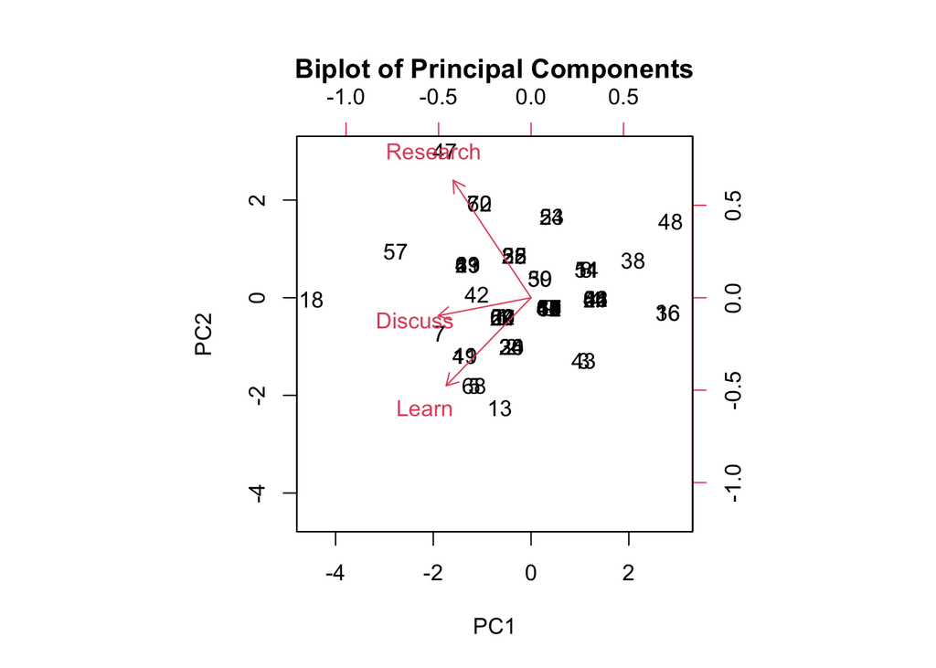

```r
delta_df <- intention_post
delta_df[, -1] <- intention_post[, -1] - intention_pre[, -1]

# Use safe colnames for lavaan
delta_df <- delta_df %>% rename(
  Discuss      = `Discuss CH`,
  Learn        = `Learn more`,
  Research     = `Support research`,
)

pca_result <- prcomp(delta_df[, c("Discuss", "Learn", "Research")], scale. = TRUE, center = TRUE, retx = TRUE)

# Visualizing the Principal Components

biplot(pca_result, main = "Biplot of Principal Components", scale = 0)
```

```r
pca_result <- prcomp(delta_df[, c("Discuss", "Learn", "Research")], scale. = TRUE)
summary(pca_result)
```

```
## Importance of components:
##                           PC1    PC2    PC3
## Standard deviation     1.2218 0.9114 0.8225
## Proportion of Variance 0.4976 0.2769 0.2255
## Cumulative Proportion  0.4976 0.7745 1.0000
```

```r
pca_result$rotation
```

```
##                 PC1        PC2        PC3
## Discuss  -0.6272834 -0.1218077  0.7692064
## Learn    -0.5738764 -0.5954063 -0.5622785
## Research -0.5264802  0.7941374 -0.3035860
```

Although the three items have the same sign (as visualised also in the plot above), PC1 explains only less than 50% of the variance. Merging the three items into a single factor would result into a significant information loss. It is therefore safer keeping the three items separated throughout the current analysis.

# Are other co-variates explaining this change?

Is the improvement dependent on external factors? We expand the analysis using other covariates derived from the questionnaire. In partiuclar we will use:

- visitors’ sense of care towards cultural heritage, as measured per CHARE Scale
- “relatedness”: is subject’s education / occupation related to CH?
- “expenses”: how easy is for the subject to afford expenses for cultural experiences?

## Retrieving CHARE theta values

The computation of CHARE scale values is not direct but requires a first calbration step of the Rasch model. Rasch model is described by:

- $\beta$: item’s difficulty
- $\theta$: subject’s ability

To avoid to compute these two parameters on the same sample we introduce here a third dataset (from chare_val.xslx), used in the first validation study of the CHARE scale, published on an [article](https://www.mdpi.com/2571-9408/8/8/317) in MDPI “Heritage”. We therefore create a new *calibration matrix* consisting of the answers (dichotomised) from:

- MDPI validation dataset (n = 52)
- Visitors of *Echoes of Loss* who only filled in the pre-test (and not post-test; n = 20)

```r
val <- read_excel("source_data/chare_val.xlsx")

# For 11-items CHARE (as validated in MDPI)
chare_items <- c("A1", "A2", "A3", "B1", "B2", "B3", "C1", "C2",
                 "D1", "D2", "D3")
chare_idx_pre <- c(12, 13, 14, 15, 16, 17, 18, 19, 21, 22, 23)

# Dichotomization functions for the Likert scales
dichotomize_val <- function(x) ifelse(x >= 4, 1, 0)
dichotomize_pre <- function(x) ifelse(x >= 3, 1, 0)

# IDs
pre_ids <- source_pre_df$`Pseudo-ID`
post_ids <- source_post_df$`Pseudo-ID`
pre_only_ids <- setdiff(pre_ids, post_ids)

# MDPI Validation data (dichotomized)
chare_val <- val[, chare_items]
chare_val <- as.data.frame(lapply(chare_val, dichotomize_val))

# Pre-only data (dichotomized)
chare_pre_only <- source_pre_df[source_pre_df$`Pseudo-ID` %in% pre_only_ids, chare_idx_pre]
names(chare_pre_only) <- chare_items
chare_pre_only <- as.data.frame(lapply(chare_pre_only, dichotomize_pre))

# Calibration matrix as concatenation of the two dfs
calibration_df <- as.matrix(rbind(chare_val, chare_pre_only))
head(calibration_df)
```

```
##      A1 A2 A3 B1 B2 B3 C1 C2 D1 D2 D3
## [1,]  0  0  0  0  0  0  0  0  0  0  0
## [2,]  1  0  0  0  1  0  0  0  0  0  0
## [3,]  1  1  0  1  1  0  0  1  1  1  0
## [4,]  1  0  0  0  0  0  1  0  1  1  0
## [5,]  1  1  1  0  0  1  0  0  1  0  1
## [6,]  0  0  0  0  0  0  0  0  0  0  0
```

We use the **library mirt** to define a Rasch model starting from “calibration_df”, from which we can extract the $\beta$ values (in the chunk below, “item_params”)

```r
library(mirt)
# Estimate Rasch model
rasch_model <- mirt(calibration_df, model = 1, itemtype = 'Rasch', verbose = FALSE)
# Extract item difficulty
item_params <- coef(rasch_model, simplify = TRUE)$items
item_params
```

```
##    a1         d g u
## A1  1 1.7349598 0 1
## A2  1 0.1572649 0 1
## A3  1 0.1572649 0 1
## B1  1 1.0777718 0 1
## B2  1 1.3986613 0 1
## B3  1 1.0777718 0 1
## C1  1 0.9732211 0 1
## C2  1 2.0944411 0 1
## D1  1 1.7349598 0 1
## D2  1 0.6643893 0 1
## D3  1 1.0777718 0 1
```

We now retrieve the answers to the items of the scale in the final sample (n = 70). We save the data into a new dataset: it has only the IDs of the visitors filling both pre- and post-survey and, as columns, the eleven items of the validated scale (“chare_idx_pre”)

```r
chare_post_subj <- source_pre_df[source_pre_df$`Pseudo-ID` %in% post_ids, chare_idx_pre]
names(chare_post_subj) <- chare_items
chare_post_subj <- as.data.frame(lapply(chare_post_subj, dichotomize_pre))
chare_post_df <- as.matrix(chare_post_subj)

head(chare_post_df)
```

```
##      A1 A2 A3 B1 B2 B3 C1 C2 D1 D2 D3
## [1,]  1  1  0  0  1  0  1  0  1  1  0
## [2,]  1  1  1  1  1  1  1  1  1  1  1
## [3,]  1  1  1  1  1  1  1  1  0  1  1
## [4,]  1  1  1  1  1  1  1  1  1  1  1
## [5,]  1  1  1  1  1  1  1  1  1  1  1
## [6,]  1  1  1  1  1  0  0  1  0  1  1
```

We use now the previous model (“rasch_model”) to compute the $\theta$ values

```r
theta <- fscores(rasch_model,
                 response.pattern = chare_post_df,
                 method = "WLE")

theta_values <- theta[, "F1"]
theta_values
```

```
##  [1] -0.9235520  2.2189508  0.9931333  2.2189508  2.2189508 -0.1360004
##  [7] -0.9235520  2.2189508  0.3465640  0.9931333  2.2189508  2.2189508
## [13]  2.2189508  2.2189508  2.2189508  0.9931333  2.2189508  2.2189508
## [19]  2.2189508  2.2189508  2.2189508  2.2189508  2.2189508  2.2189508
## [25]  2.2189508  0.9931333  2.2189508  2.2189508  0.3465640  0.9931333
## [31]  2.2189508  2.2189508  2.2189508  2.2189508  2.2189508  2.2189508
## [37]  2.2189508  2.2189508  2.2189508  2.2189508  0.9931333  0.9931333
## [43]  2.2189508  2.2189508  2.2189508  2.2189508  2.2189508  0.9931333
## [49]  2.2189508  2.2189508  2.2189508  0.3465640  2.2189508  2.2189508
## [55]  2.2189508  2.2189508  0.9931333  2.2189508  2.2189508  2.2189508
## [61]  2.2189508  2.2189508  2.2189508  2.2189508  2.2189508  2.2189508
## [67]  2.2189508  2.2189508  0.9931333  2.2189508
```

## Co-variate analysis with ANCOVA

To perform the full covariate analysis we enrich the original datasets with inofrmation concerning *relatedness* (index 10 in the source df), *expenses* (with index 11) and *$\theta$ values*. We merge all these information into a single dataframe, named “covar_df”

```r
# Create custom DF
covar_df <- data.frame(
  `Pseudo-ID` = intention_pre$`Pseudo-ID`,
  relatedness = source_pre_df[match(intention_pre$`Pseudo-ID`, source_pre_df$`Pseudo-ID`), 10],
  expenses = source_pre_df[match(intention_pre$`Pseudo-ID`, source_pre_df$`Pseudo-ID`), 11],
  theta = theta_values,
  intention_pre[, -1],
  intention_post[, -1]
)

# Rinomina tutte le colonne
colnames(covar_df) <- c("ID",
                        "relatedness", "expenses", "theta",
                        "discuss_pre", "learn_pre", "research_pre",
                        "collective_pre", "individual_pre", "participative_pre", "support_pre",
                        "discuss_post", "learn_post", "research_post",
                        "collective_post", "individual_post", "participative_post", "support_post")

head(covar_df)
```

|  | ID | relatedness | expenses | theta | discuss_pre | learn_pre | research_pre | collective_pre | individual_pre | participative_pre | support_pre | discuss_post | learn_post | research_post | collective_post | individual_post | participative_post | support_post |
| --- | --- | --- | --- | --- | --- | --- | --- | --- | --- | --- | --- | --- | --- | --- | --- | --- | --- | --- |
| 1 | DH08A | 2 | 2 | -0.9235520 | 3 | 4 | 3 | 4 | 4 | 4 | 2 | 4 | 4 | 3 | 4 | 4 | 4 | 3 |
| 2 | DH08B | 4 | 4 | 2.2189508 | 4 | 4 | 4 | 5 | 4 | 4 | 2 | 4 | 5 | 4 | 4 | 4 | 4 | 4 |
| 3 | DH08D | 4 | 4 | 0.9931333 | 4 | 4 | 2 | 4 | 1 | 1 | 4 | 4 | 4 | 1 | 4 | 1 | 1 | 4 |
| 4 | DH08C | 5 | 5 | 2.2189508 | 4 | 4 | 4 | 5 | 4 | 4 | 4 | 3 | 4 | 4 | 4 | 5 | 4 | 4 |
| 5 | DH08E | 4 | 4 | 2.2189508 | 5 | 3 | 5 | 5 | 5 | 5 | 3 | 5 | 5 | 5 | 5 | 5 | 5 | 5 |
| 6 | DH08F | 2 | 4 | -0.1360004 | 3 | 4 | 4 | 4 | 3 | 4 | 4 | 4 | 4 | 4 | 5 | 4 | 4 | 4 |

We use this data inside an ancillary function to create the long_data item requested for **ANCOVA**. As for the Wilcoxon signed rank, we then run 7 ANCOVA separately: in each of them we want to see which of the covariate ($\theta$, relatedness, expenses) impacts on the effect of the visit to *Echoes of Loss*

### Theta as co-variate

We start with first only theta:

```r
library(car)
library(lme4)
create_long_data <- function(item_name) {
  data.frame(
    ID    = rep(covar_df$ID, 2),
    time  = rep(c("pre", "post"), each = nrow(covar_df)),
    value = c(covar_df[[paste0(item_name, "_pre")]],
              covar_df[[paste0(item_name, "_post")]]),
    theta = rep(covar_df$theta, 2),
    relatedness = rep(covar_df$relatedness, 2),
    expenses = rep(covar_df$expenses, 2)
  )
}

print("=== DISCUSS ===")
```

```
## [1] "=== DISCUSS ==="
```

```r
long_discuss <- create_long_data("discuss")
model_discuss <- lmer(value ~ time * theta + (1|`ID`),
                      data = long_discuss)
print(model_discuss)
```

```
## Linear mixed model fit by REML ['lmerMod']
## Formula: value ~ time * theta + (1 | ID)
##    Data: long_discuss
## REML criterion at convergence: 313.2019
## Random effects:
##  Groups   Name        Std.Dev.
##  ID       (Intercept) 0.743
##  Residual             0.455
## Number of obs: 140, groups:  ID, 70
## Fixed Effects:
##   (Intercept)        timepre          theta  timepre:theta
##       4.13215       -0.50226       -0.05629        0.20308
```

```r
print(Anova(model_discuss, type = 3))
```

```
## Analysis of Deviance Table (Type III Wald chisquare tests)
##
## Response: value
##                Chisq Df Pr(>Chisq)
## (Intercept) 231.2105  1    < 2e-16 ***
## time          6.2614  1    0.01234 *
## theta         0.1703  1    0.67987
## time:theta    4.0626  1    0.04384 *
## ---
## Signif. codes:  0 '***' 0.001 '**' 0.01 '*' 0.05 '.' 0.1 ' ' 1
```

```r
print("=== LEARN ===")
```

```
## [1] "=== LEARN ==="
```

```r
long_learn <- create_long_data("learn")
model_learn <- lmer(value ~ time * theta + (1|`ID`),
                    data = long_learn)
print(model_learn)
```

```
## Linear mixed model fit by REML ['lmerMod']
## Formula: value ~ time * theta + (1 | ID)
##    Data: long_learn
## REML criterion at convergence: 317.5558
## Random effects:
##  Groups   Name        Std.Dev.
##  ID       (Intercept) 0.6126
##  Residual             0.5298
## Number of obs: 140, groups:  ID, 70
## Fixed Effects:
##   (Intercept)        timepre          theta  timepre:theta
##      4.187804      -0.269491      -0.001135       0.107633
```

```r
print(Anova(model_learn, type = 3))
```

```
## Analysis of Deviance Table (Type III Wald chisquare tests)
##
## Response: value
##                Chisq Df Pr(>Chisq)
## (Intercept) 274.8188  1     <2e-16 ***
## time          1.3299  1     0.2488
## theta         0.0001  1     0.9929
## time:theta    0.8420  1     0.3588
## ---
## Signif. codes:  0 '***' 0.001 '**' 0.01 '*' 0.05 '.' 0.1 ' ' 1
```

```r
print("=== RESEARCH ===")
```

```
## [1] "=== RESEARCH ==="
```

```r
long_research <- create_long_data("research")
model_research <- lmer(value ~ time * theta + (1|`ID`),
                       data = long_research)
print(model_research)
```

```
## Linear mixed model fit by REML ['lmerMod']
## Formula: value ~ time * theta + (1 | ID)
##    Data: long_research
## REML criterion at convergence: 357.3137
## Random effects:
##  Groups   Name        Std.Dev.
##  ID       (Intercept) 0.8915
##  Residual             0.5273
## Number of obs: 140, groups:  ID, 70
## Fixed Effects:
##   (Intercept)        timepre          theta  timepre:theta
##       3.34614       -0.22829        0.23111       -0.02344
```

```r
print(Anova(model_research, type = 3))
```

```
## Analysis of Deviance Table (Type III Wald chisquare tests)
##
## Response: value
##                Chisq Df Pr(>Chisq)
## (Intercept) 107.2757  1     <2e-16 ***
## time          0.9632  1     0.3264
## theta         2.0312  1     0.1541
## time:theta    0.0403  1     0.8409
## ---
## Signif. codes:  0 '***' 0.001 '**' 0.01 '*' 0.05 '.' 0.1 ' ' 1
```

```r
print("=== COLLECTIVE ===")
```

```
## [1] "=== COLLECTIVE ==="
```

```r
long_collective <- create_long_data("collective")
model_collective <- lmer(value ~ time * theta + (1|`ID`),
                         data = long_collective)
print(model_collective)
```

```
## Linear mixed model fit by REML ['lmerMod']
## Formula: value ~ time * theta + (1 | ID)
##    Data: long_collective
## REML criterion at convergence: 321.6414
## Random effects:
##  Groups   Name        Std.Dev.
##  ID       (Intercept) 0.7182
##  Residual             0.4914
## Number of obs: 140, groups:  ID, 70
## Fixed Effects:
##   (Intercept)        timepre          theta  timepre:theta
##       4.30919        0.01276       -0.02828       -0.03022
```

```r
print(Anova(model_collective, type = 3))
```

```
## Analysis of Deviance Table (Type III Wald chisquare tests)
##
## Response: value
##                Chisq Df Pr(>Chisq)
## (Intercept) 252.0570  1     <2e-16 ***
## time          0.0035  1     0.9531
## theta         0.0431  1     0.8355
## time:theta    0.0772  1     0.7812
## ---
## Signif. codes:  0 '***' 0.001 '**' 0.01 '*' 0.05 '.' 0.1 ' ' 1
```

```r
print("=== INDIVIDUAL ===")
```

```
## [1] "=== INDIVIDUAL ==="
```

```r
long_individual <- create_long_data("individual")
model_individual <- lmer(value ~ time * theta + (1|`ID`),
                         data = long_individual)
print(model_individual)
```

```
## Linear mixed model fit by REML ['lmerMod']
## Formula: value ~ time * theta + (1 | ID)
##    Data: long_individual
## REML criterion at convergence: 378.4172
## Random effects:
##  Groups   Name        Std.Dev.
##  ID       (Intercept) 0.7628
##  Residual             0.6643
## Number of obs: 140, groups:  ID, 70
## Fixed Effects:
##   (Intercept)        timepre          theta  timepre:theta
##       4.04117       -0.39317       -0.06119        0.08945
```

```r
print(Anova(model_individual, type = 3))
```

```
## Analysis of Deviance Table (Type III Wald chisquare tests)
##
## Response: value
##                Chisq Df Pr(>Chisq)
## (Intercept) 164.0542  1     <2e-16 ***
## time          1.8003  1     0.1797
## theta         0.1493  1     0.6992
## time:theta    0.3698  1     0.5431
## ---
## Signif. codes:  0 '***' 0.001 '**' 0.01 '*' 0.05 '.' 0.1 ' ' 1
```

```r
print("=== PARTICIPATIVE ===")
```

```
## [1] "=== PARTICIPATIVE ==="
```

```r
long_participative <- create_long_data("participative")
model_participative <- lmer(value ~ time * theta + (1|`ID`),
                            data = long_participative)
print(model_participative)
```

```
## Linear mixed model fit by REML ['lmerMod']
## Formula: value ~ time * theta + (1 | ID)
##    Data: long_participative
## REML criterion at convergence: 341.8461
## Random effects:
##  Groups   Name        Std.Dev.
##  ID       (Intercept) 0.7864
##  Residual             0.5233
## Number of obs: 140, groups:  ID, 70
## Fixed Effects:
##   (Intercept)        timepre          theta  timepre:theta
##       4.02833       -0.10895        0.06224       -0.02619
```

```r
print(Anova(model_participative, type = 3))
```

```
## Analysis of Deviance Table (Type III Wald chisquare tests)
##
## Response: value
##                Chisq Df Pr(>Chisq)
## (Intercept) 186.9413  1     <2e-16 ***
## time          0.2228  1     0.6369
## theta         0.1771  1     0.6739
## time:theta    0.0511  1     0.8212
## ---
## Signif. codes:  0 '***' 0.001 '**' 0.01 '*' 0.05 '.' 0.1 ' ' 1
```

```r
print("=== SUPPORT ===")
```

```
## [1] "=== SUPPORT ==="
```

```r
long_support <- create_long_data("support")
model_support <- lmer(value ~ time * theta + (1|`ID`),
                      data = long_support)
print(model_support)
```

```
## Linear mixed model fit by REML ['lmerMod']
## Formula: value ~ time * theta + (1 | ID)
##    Data: long_support
## REML criterion at convergence: 388.8361
## Random effects:
##  Groups   Name        Std.Dev.
##  ID       (Intercept) 0.4966
##  Residual             0.8336
## Number of obs: 140, groups:  ID, 70
## Fixed Effects:
##   (Intercept)        timepre          theta  timepre:theta
##        3.9288        -0.7850         0.2250         0.1083
```

```r
print(Anova(model_support, type = 3))
```

```
## Analysis of Deviance Table (Type III Wald chisquare tests)
##
## Response: value
##                Chisq Df Pr(>Chisq)
## (Intercept) 168.5145  1    < 2e-16 ***
## time          4.5571  1    0.03278 *
## theta         2.1938  1    0.13857
## time:theta    0.3442  1    0.55743
## ---
## Signif. codes:  0 '***' 0.001 '**' 0.01 '*' 0.05 '.' 0.1 ' ' 1
```

We then apply the Bonferroni correction on the full sample:

```r
# Extract all p-values for time:theta interaction only (7 tests)
p_interactions <- c(
  Anova(model_discuss, type = 3)["time:theta", "Pr(>Chisq)"],
  Anova(model_learn, type = 3)["time:theta", "Pr(>Chisq)"],
  Anova(model_research, type = 3)["time:theta", "Pr(>Chisq)"],
  Anova(model_collective, type = 3)["time:theta", "Pr(>Chisq)"],
  Anova(model_individual, type = 3)["time:theta", "Pr(>Chisq)"],
  Anova(model_participative, type = 3)["time:theta", "Pr(>Chisq)"],
  Anova(model_support, type = 3)["time:theta", "Pr(>Chisq)"]
)

# Apply Holm correction
p_holm <- p.adjust(p_interactions, method = "holm")

# Create results dataframe
results_corrections <- data.frame(
  item = c("discuss", "learn", "research", "collective", "individual", "participative", "support"),
  p_raw = p_interactions,
  p_holm = p_holm
)

results_corrections
```

| item | p_raw | p_holm |
| --- | --- | --- |
| discuss | 0.04384249 | 0.3068975 |
| learn | 0.35883255 | 1.0000000 |
| research | 0.84088731 | 1.0000000 |
| collective | 0.78115129 | 1.0000000 |
| individual | 0.54309078 | 1.0000000 |
| participative | 0.82116991 | 1.0000000 |
| support | 0.55742710 | 1.0000000 |

#### Ceiling correction on time:theta

We apply the ceiling effecti mitigation as in the Wilcoxon signed rank test (excluding those with pre-test answers already at the top of the Likert scale)

```r
# Function to create long format data with ceiling correction (exclude pre == 5)
create_long_data_ceiling <- function(item_name) {
  # Get pre and post values
  pre_vals <- covar_df[[paste0(item_name, "_pre")]]
  post_vals <- covar_df[[paste0(item_name, "_post")]]

  # Identify IDs where pre < 5 (exclude ceiling at pre)
  keep_ids <- pre_vals < 5

  # Filter all variables
  filtered_df <- covar_df[keep_ids, ]

  # Create long format with filtered data - includes all covariates for flexible model specification
  data.frame(
    `Pseudo-ID` = rep(filtered_df$ID, 2),
    time  = rep(c("pre", "post"), each = nrow(filtered_df)),
    value = c(filtered_df[[paste0(item_name, "_pre")]],
              filtered_df[[paste0(item_name, "_post")]]),
    theta = rep(filtered_df$theta, 2),
    relatedness = rep(filtered_df$relatedness, 2),
    expenses = rep(filtered_df$expenses, 2)
  )
}

# Run mixed models with ceiling correction for all 7 items
library(lme4)
library(car)

print("=== DISCUSS (ceiling corrected) ===")
```

```
## [1] "=== DISCUSS (ceiling corrected) ==="
```

```r
long_discuss_c <- create_long_data_ceiling("discuss")
model_discuss_c <- lmer(value ~ time * theta + (1|`Pseudo.ID`), data = long_discuss_c)
print(model_discuss_c)
```

```
## Linear mixed model fit by REML ['lmerMod']
## Formula: value ~ time * theta + (1 | Pseudo.ID)
##    Data: long_discuss_c
## REML criterion at convergence: 203.1369
## Random effects:
##  Groups    Name        Std.Dev.
##  Pseudo.ID (Intercept) 0.4865
##  Residual              0.4915
## Number of obs: 100, groups:  Pseudo.ID, 50
## Fixed Effects:
##   (Intercept)        timepre          theta  timepre:theta
##        4.1924        -0.6412        -0.2834         0.2309
```

```r
print(Anova(model_discuss_c, type = 3))
```

```
## Analysis of Deviance Table (Type III Wald chisquare tests)
##
## Response: value
##                Chisq Df Pr(>Chisq)
## (Intercept) 355.8315  1  < 2.2e-16 ***
## time          8.2397  1   0.004098 **
## theta         6.0871  1   0.013617 *
## time:theta    4.0004  1   0.045488 *
## ---
## Signif. codes:  0 '***' 0.001 '**' 0.01 '*' 0.05 '.' 0.1 ' ' 1
```

```r
print("=== LEARN (ceiling corrected) ===")
```

```
## [1] "=== LEARN (ceiling corrected) ==="
```

```r
long_learn_c <- create_long_data_ceiling("learn")
model_learn_c <- lmer(value ~ time * theta + (1|`Pseudo.ID`), data = long_learn_c)
print(model_learn_c)
```

```
## Linear mixed model fit by REML ['lmerMod']
## Formula: value ~ time * theta + (1 | Pseudo.ID)
##    Data: long_learn_c
## REML criterion at convergence: 187.8356
## Random effects:
##  Groups    Name        Std.Dev.
##  Pseudo.ID (Intercept) 0.4496
##  Residual              0.5306
## Number of obs: 90, groups:  Pseudo.ID, 45
## Fixed Effects:
##   (Intercept)        timepre          theta  timepre:theta
##        4.1496        -0.6150        -0.1329         0.1817
```

```r
print(Anova(model_learn_c, type = 3))
```

```
## Analysis of Deviance Table (Type III Wald chisquare tests)
##
## Response: value
##                Chisq Df Pr(>Chisq)
## (Intercept) 283.9216  1    < 2e-16 ***
## time          5.3562  1    0.02065 *
## theta         1.1399  1    0.28568
## time:theta    1.8303  1    0.17609
## ---
## Signif. codes:  0 '***' 0.001 '**' 0.01 '*' 0.05 '.' 0.1 ' ' 1
```

```r
print("=== RESEARCH (ceiling corrected) ===")
```

```
## [1] "=== RESEARCH (ceiling corrected) ==="
```

```r
long_research_c <- create_long_data_ceiling("research")
model_research_c <- lmer(value ~ time * theta + (1|`Pseudo.ID`), data = long_research_c)
print(model_research_c)
```

```
## Linear mixed model fit by REML ['lmerMod']
## Formula: value ~ time * theta + (1 | Pseudo.ID)
##    Data: long_research_c
## REML criterion at convergence: 270.873
## Random effects:
##  Groups    Name        Std.Dev.
##  Pseudo.ID (Intercept) 0.6952
##  Residual              0.5536
## Number of obs: 112, groups:  Pseudo.ID, 56
## Fixed Effects:
##   (Intercept)        timepre          theta  timepre:theta
##       3.11573       -0.33114        0.21083       -0.02407
```

```r
print(Anova(model_research_c, type = 3))
```

```
## Analysis of Deviance Table (Type III Wald chisquare tests)
##
## Response: value
##                Chisq Df Pr(>Chisq)
## (Intercept) 110.3796  1     <2e-16 ***
## time          1.6064  1     0.2050
## theta         1.9997  1     0.1573
## time:theta    0.0336  1     0.8546
## ---
## Signif. codes:  0 '***' 0.001 '**' 0.01 '*' 0.05 '.' 0.1 ' ' 1
```

```r
print("=== COLLECTIVE (ceiling corrected) ===")
```

```
## [1] "=== COLLECTIVE (ceiling corrected) ==="
```

```r
long_collective_c <- create_long_data_ceiling("collective")
model_collective_c <- lmer(value ~ time * theta + (1|`Pseudo.ID`), data = long_collective_c)
print(model_collective_c)
```

```
## Linear mixed model fit by REML ['lmerMod']
## Formula: value ~ time * theta + (1 | Pseudo.ID)
##    Data: long_collective_c
## REML criterion at convergence: 160.7138
## Random effects:
##  Groups    Name        Std.Dev.
##  Pseudo.ID (Intercept) 0.5201
##  Residual              0.5272
## Number of obs: 74, groups:  Pseudo.ID, 37
## Fixed Effects:
##   (Intercept)        timepre          theta  timepre:theta
##       4.08753       -0.12291       -0.15781       -0.09945
```

```r
print(Anova(model_collective_c, type = 3))
```

```
## Analysis of Deviance Table (Type III Wald chisquare tests)
##
## Response: value
##                Chisq Df Pr(>Chisq)
## (Intercept) 221.3682  1     <2e-16 ***
## time          0.1975  1     0.6568
## theta         1.2625  1     0.2612
## time:theta    0.4946  1     0.4819
## ---
## Signif. codes:  0 '***' 0.001 '**' 0.01 '*' 0.05 '.' 0.1 ' ' 1
```

```r
print("=== INDIVIDUAL (ceiling corrected) ===")
```

```
## [1] "=== INDIVIDUAL (ceiling corrected) ==="
```

```r
long_individual_c <- create_long_data_ceiling("individual")
model_individual_c <- lmer(value ~ time * theta + (1|`Pseudo.ID`), data = long_individual_c)
print(model_individual_c)
```

```
## Linear mixed model fit by REML ['lmerMod']
## Formula: value ~ time * theta + (1 | Pseudo.ID)
##    Data: long_individual_c
## REML criterion at convergence: 259.7353
## Random effects:
##  Groups    Name        Std.Dev.
##  Pseudo.ID (Intercept) 0.6285
##  Residual              0.6239
## Number of obs: 104, groups:  Pseudo.ID, 52
## Fixed Effects:
##   (Intercept)        timepre          theta  timepre:theta
##      3.726387      -0.479991      -0.008122       0.010093
```

```r
print(Anova(model_individual_c, type = 3))
```

```
## Analysis of Deviance Table (Type III Wald chisquare tests)
##
## Response: value
##                Chisq Df Pr(>Chisq)
## (Intercept) 146.4944  1     <2e-16 ***
## time          2.4487  1     0.1176
## theta         0.0028  1     0.9581
## time:theta    0.0043  1     0.9477
## ---
## Signif. codes:  0 '***' 0.001 '**' 0.01 '*' 0.05 '.' 0.1 ' ' 1
```

```r
print("=== PARTICIPATIVE (ceiling corrected) ===")
```

```
## [1] "=== PARTICIPATIVE (ceiling corrected) ==="
```

```r
long_participative_c <- create_long_data_ceiling("participative")
model_participative_c <- lmer(value ~ time * theta + (1|`Pseudo.ID`), data = long_participative_c)
print(model_participative_c)
```

```
## Linear mixed model fit by REML ['lmerMod']
## Formula: value ~ time * theta + (1 | Pseudo.ID)
##    Data: long_participative_c
## REML criterion at convergence: 213.96
## Random effects:
##  Groups    Name        Std.Dev.
##  Pseudo.ID (Intercept) 0.5832
##  Residual              0.5880
## Number of obs: 90, groups:  Pseudo.ID, 45
## Fixed Effects:
##   (Intercept)        timepre          theta  timepre:theta
##       3.57578       -0.16388        0.09867       -0.09301
```

```r
print(Anova(model_participative_c, type = 3))
```

```
## Analysis of Deviance Table (Type III Wald chisquare tests)
##
## Response: value
##                Chisq Df Pr(>Chisq)
## (Intercept) 143.1072  1     <2e-16 ***
## time          0.2982  1     0.5850
## theta         0.4361  1     0.5090
## time:theta    0.3843  1     0.5353
## ---
## Signif. codes:  0 '***' 0.001 '**' 0.01 '*' 0.05 '.' 0.1 ' ' 1
```

```r
print("=== SUPPORT (ceiling corrected) ===")
```

```
## [1] "=== SUPPORT (ceiling corrected) ==="
```

```r
long_support_c <- create_long_data_ceiling("support")
model_support_c <- lmer(value ~ time * theta + (1|`Pseudo.ID`), data = long_support_c)
print(model_support_c)
```

```
## Linear mixed model fit by REML ['lmerMod']
## Formula: value ~ time * theta + (1 | Pseudo.ID)
##    Data: long_support_c
## REML criterion at convergence: 225.3979
## Random effects:
##  Groups    Name        Std.Dev.
##  Pseudo.ID (Intercept) 0.2434
##  Residual              0.7886
## Number of obs: 90, groups:  Pseudo.ID, 45
## Fixed Effects:
##   (Intercept)        timepre          theta  timepre:theta
##       3.79581       -0.96981        0.20691       -0.06849
```

```r
print(Anova(model_support_c, type = 3))
```

```
## Analysis of Deviance Table (Type III Wald chisquare tests)
##
## Response: value
##                Chisq Df Pr(>Chisq)
## (Intercept) 192.3541  1  < 2.2e-16 ***
## time          6.8762  1   0.008735 **
## theta         2.1653  1   0.141160
## time:theta    0.1299  1   0.718526
## ---
## Signif. codes:  0 '***' 0.001 '**' 0.01 '*' 0.05 '.' 0.1 ' ' 1
```

We only verify a significant interaction between time (i.e. the visit to the exhibition) and theta (sense of care) in the “discussion” item. We then apply the Bonferroni correction on the corrected sample:

```r
# Extract p-values for time:theta interaction from ceiling-corrected models (1 covariate)
p_interactions_c <- c(
  Anova(model_discuss_c, type = 3)["time:theta", "Pr(>Chisq)"],
  Anova(model_learn_c, type = 3)["time:theta", "Pr(>Chisq)"],
  Anova(model_research_c, type = 3)["time:theta", "Pr(>Chisq)"],
  Anova(model_collective_c, type = 3)["time:theta", "Pr(>Chisq)"],
  Anova(model_individual_c, type = 3)["time:theta", "Pr(>Chisq)"],
  Anova(model_participative_c, type = 3)["time:theta", "Pr(>Chisq)"],
  Anova(model_support_c, type = 3)["time:theta", "Pr(>Chisq)"]
)

# Apply Holm correction
p_holm_c <- p.adjust(p_interactions_c, method = "holm")

# Create results dataframe
results_corrections_c <- data.frame(
  item = c("discuss", "learn", "research", "collective", "individual", "participative", "support"),
  p_raw = p_interactions_c,
  p_holm = p_holm_c
)

results_corrections_c
```

| item | p_raw | p_holm |
| --- | --- | --- |
| discuss | 0.04548836 | 0.3184185 |
| learn | 0.17608984 | 1.0000000 |
| research | 0.85461899 | 1.0000000 |
| collective | 0.48186070 | 1.0000000 |
| individual | 0.94769318 | 1.0000000 |
| participative | 0.53528649 | 1.0000000 |
| support | 0.71852570 | 1.0000000 |

After the correction, no item shows a significant interaction between variable and covariate.

### Theta, relatedness, expenses as co-variate

We enrich the model taking also the other two factors into account (relatedness and expense)

```r
print("=== DISCUSS (3 covariates) ===")
```

```
## [1] "=== DISCUSS (3 covariates) ==="
```

```r
model_discuss_3cov <- lmer(value ~ time * (theta + relatedness + expenses) + (1|`ID`), data = long_discuss)
print(Anova(model_discuss_3cov, type = 3))
```

```
## Analysis of Deviance Table (Type III Wald chisquare tests)
##
## Response: value
##                    Chisq Df Pr(>Chisq)
## (Intercept)      57.0757  1  4.194e-14 ***
## time              2.7183  1     0.0992 .
## theta             0.5816  1     0.4457
## relatedness       0.1589  1     0.6901
## expenses          0.4454  1     0.5045
## time:theta        2.6596  1     0.1029
## time:relatedness  0.5312  1     0.4661
## time:expenses     0.1867  1     0.6657
## ---
## Signif. codes:  0 '***' 0.001 '**' 0.01 '*' 0.05 '.' 0.1 ' ' 1
```

```r
print("=== LEARN (3 covariates) ===")
```

```
## [1] "=== LEARN (3 covariates) ==="
```

```r
model_learn_3cov <- lmer(value ~ time * (theta + relatedness + expenses) + (1|`ID`), data = long_learn)
print(Anova(model_learn_3cov, type = 3))
```

```
## Analysis of Deviance Table (Type III Wald chisquare tests)
##
## Response: value
##                    Chisq Df Pr(>Chisq)
## (Intercept)      72.0035  1     <2e-16 ***
## time              1.9026  1     0.1678
## theta             0.1136  1     0.7360
## relatedness       0.9288  1     0.3352
## expenses          0.0318  1     0.8585
## time:theta        0.1740  1     0.6766
## time:relatedness  1.1992  1     0.2735
## time:expenses     0.0207  1     0.8855
## ---
## Signif. codes:  0 '***' 0.001 '**' 0.01 '*' 0.05 '.' 0.1 ' ' 1
```

```r
print("=== RESEARCH (3 covariates) ===")
```

```
## [1] "=== RESEARCH (3 covariates) ==="
```

```r
model_research_3cov <- lmer(value ~ time * (theta + relatedness + expenses) + (1|`ID`), data = long_research)
print(Anova(model_research_3cov, type = 3))
```

```
## Analysis of Deviance Table (Type III Wald chisquare tests)
##
## Response: value
##                    Chisq Df Pr(>Chisq)
## (Intercept)      31.8284  1  1.684e-08 ***
## time              1.7871  1    0.18128
## theta             1.5833  1    0.20829
## relatedness       0.1312  1    0.71721
## expenses          0.1659  1    0.68375
## time:theta        0.3290  1    0.56627
## time:relatedness  3.5941  1    0.05798 .
## time:expenses     1.1497  1    0.28360
## ---
## Signif. codes:  0 '***' 0.001 '**' 0.01 '*' 0.05 '.' 0.1 ' ' 1
```

```r
print("=== COLLECTIVE (3 covariates) ===")
```

```
## [1] "=== COLLECTIVE (3 covariates) ==="
```

```r
model_collective_3cov <- lmer(value ~ time * (theta + relatedness + expenses) + (1|`ID`), data = long_collective)
print(Anova(model_collective_3cov, type = 3))
```

```
## Analysis of Deviance Table (Type III Wald chisquare tests)
##
## Response: value
##                    Chisq Df Pr(>Chisq)
## (Intercept)      73.7371  1     <2e-16 ***
## time              0.0796  1     0.7778
## theta             0.0315  1     0.8591
## relatedness       0.0195  1     0.8888
## expenses          0.0305  1     0.8613
## time:theta        0.0091  1     0.9240
## time:relatedness  0.0338  1     0.8541
## time:expenses     0.4008  1     0.5267
## ---
## Signif. codes:  0 '***' 0.001 '**' 0.01 '*' 0.05 '.' 0.1 ' ' 1
```

```r
print("=== INDIVIDUAL (3 covariates) ===")
```

```
## [1] "=== INDIVIDUAL (3 covariates) ==="
```

```r
model_individual_3cov <- lmer(value ~ time * (theta + relatedness + expenses) + (1|`ID`), data = long_individual)
print(Anova(model_individual_3cov, type = 3))
```

```
## Analysis of Deviance Table (Type III Wald chisquare tests)
##
## Response: value
##                    Chisq Df Pr(>Chisq)
## (Intercept)      47.3578  1  5.914e-12 ***
## time              0.3548  1     0.5514
## theta             0.1344  1     0.7139
## relatedness       0.0099  1     0.9208
## expenses          0.0369  1     0.8477
## time:theta        0.3936  1     0.5304
## time:relatedness  0.2375  1     0.6260
## time:expenses     0.6715  1     0.4125
## ---
## Signif. codes:  0 '***' 0.001 '**' 0.01 '*' 0.05 '.' 0.1 ' ' 1
```

```r
print("=== PARTICIPATIVE (3 covariates) ===")
```

```
## [1] "=== PARTICIPATIVE (3 covariates) ==="
```

```r
model_participative_3cov <- lmer(value ~ time * (theta + relatedness + expenses) + (1|`ID`), data = long_participative)
print(Anova(model_participative_3cov, type = 3))
```

```
## Analysis of Deviance Table (Type III Wald chisquare tests)
##
## Response: value
##                    Chisq Df Pr(>Chisq)
## (Intercept)      47.8015  1  4.716e-12 ***
## time              0.2292  1     0.6321
## theta             0.0116  1     0.9143
## relatedness       0.6598  1     0.4166
## expenses          0.0362  1     0.8491
## time:theta        0.1074  1     0.7431
## time:relatedness  0.0021  1     0.9632
## time:expenses     0.1757  1     0.6751
## ---
## Signif. codes:  0 '***' 0.001 '**' 0.01 '*' 0.05 '.' 0.1 ' ' 1
```

```r
print("=== SUPPORT (3 covariates) ===")
```

```
## [1] "=== SUPPORT (3 covariates) ==="
```

```r
model_support_3cov <- lmer(value ~ time * (theta + relatedness + expenses) + (1|`ID`), data = long_support)
print(Anova(model_support_3cov, type = 3))
```

```
## Analysis of Deviance Table (Type III Wald chisquare tests)
##
## Response: value
##                    Chisq Df Pr(>Chisq)
## (Intercept)      43.7315  1  3.767e-11 ***
## time              3.2621  1     0.0709 .
## theta             1.1104  1     0.2920
## relatedness       0.0731  1     0.7868
## expenses          0.1753  1     0.6754
## time:theta        0.0306  1     0.8610
## time:relatedness  0.7507  1     0.3863
## time:expenses     0.0008  1     0.9770
## ---
## Signif. codes:  0 '***' 0.001 '**' 0.01 '*' 0.05 '.' 0.1 ' ' 1
```

As above, we then apply Holm - Bonferroni correction:

```r
# Extract p-values for all three interactions from 3-covariate models (no ceiling)
p_interactions_3cov <- c(
  # time:theta interactions
  Anova(model_discuss_3cov, type = 3)["time:theta", "Pr(>Chisq)"],
  Anova(model_learn_3cov, type = 3)["time:theta", "Pr(>Chisq)"],
  Anova(model_research_3cov, type = 3)["time:theta", "Pr(>Chisq)"],
  Anova(model_collective_3cov, type = 3)["time:theta", "Pr(>Chisq)"],
  Anova(model_individual_3cov, type = 3)["time:theta", "Pr(>Chisq)"],
  Anova(model_participative_3cov, type = 3)["time:theta", "Pr(>Chisq)"],
  Anova(model_support_3cov, type = 3)["time:theta", "Pr(>Chisq)"],

  # time:relatedness interactions
  Anova(model_discuss_3cov, type = 3)["time:relatedness", "Pr(>Chisq)"],
  Anova(model_learn_3cov, type = 3)["time:relatedness", "Pr(>Chisq)"],
  Anova(model_research_3cov, type = 3)["time:relatedness", "Pr(>Chisq)"],
  Anova(model_collective_3cov, type = 3)["time:relatedness", "Pr(>Chisq)"],
  Anova(model_individual_3cov, type = 3)["time:relatedness", "Pr(>Chisq)"],
  Anova(model_participative_3cov, type = 3)["time:relatedness", "Pr(>Chisq)"],
  Anova(model_support_3cov, type = 3)["time:relatedness", "Pr(>Chisq)"],

  # time:expenses interactions
  Anova(model_discuss_3cov, type = 3)["time:expenses", "Pr(>Chisq)"],
  Anova(model_learn_3cov, type = 3)["time:expenses", "Pr(>Chisq)"],
  Anova(model_research_3cov, type = 3)["time:expenses", "Pr(>Chisq)"],
  Anova(model_collective_3cov, type = 3)["time:expenses", "Pr(>Chisq)"],
  Anova(model_individual_3cov, type = 3)["time:expenses", "Pr(>Chisq)"],
  Anova(model_participative_3cov, type = 3)["time:expenses", "Pr(>Chisq)"],
  Anova(model_support_3cov, type = 3)["time:expenses", "Pr(>Chisq)"]
)

# Apply Holm correction
p_holm_3cov <- p.adjust(p_interactions_3cov, method = "holm")

# Create results dataframe
results_corrections_3cov <- data.frame(
  interaction = rep(c("time:theta", "time:relatedness", "time:expenses"), each = 7),
  item = rep(c("discuss", "learn", "research", "collective", "individual", "participative", "support"), 3),
  p_raw = p_interactions_3cov,
  p_holm = p_holm_3cov
)

results_corrections_3cov
```

| interaction | item | p_raw | p_holm |
| --- | --- | --- | --- |
| time:theta | discuss | 0.10292864 | 1 |
| time:theta | learn | 0.67656828 | 1 |
| time:theta | research | 0.56627420 | 1 |
| time:theta | collective | 0.92402380 | 1 |
| time:theta | individual | 0.53040940 | 1 |
| time:theta | participative | 0.74309798 | 1 |
| time:theta | support | 0.86103075 | 1 |
| time:relatedness | discuss | 0.46610198 | 1 |
| time:relatedness | learn | 0.27348482 | 1 |
| time:relatedness | research | 0.05798395 | 1 |

[output cut: 11 more lines]

Even without the correction, no value is under the 0.05 threshold: the covariance analysis on the three factors is not returning significant results.

#### Ceiling correction on time:(theta+expenses+relatedness)

We apply again the ceiling effect mitigation:

```r
print("=== DISCUSS (3 covariates, ceiling corrected) ===")
```

```
## [1] "=== DISCUSS (3 covariates, ceiling corrected) ==="
```

```r
long_discuss_c <- create_long_data_ceiling("discuss")
model_discuss_3cov_c <- lmer(value ~ time * (theta + relatedness + expenses) + (1|`Pseudo.ID`), data = long_discuss_c)
print(Anova(model_discuss_3cov_c, type = 3))
```

```
## Analysis of Deviance Table (Type III Wald chisquare tests)
##
## Response: value
##                    Chisq Df Pr(>Chisq)
## (Intercept)      98.1380  1    < 2e-16 ***
## time              3.6206  1    0.05707 .
## theta             5.3497  1    0.02073 *
## relatedness       2.0443  1    0.15278
## expenses          2.4580  1    0.11693
## time:theta        2.2531  1    0.13335
## time:relatedness  0.1182  1    0.73102
## time:expenses     0.0742  1    0.78533
## ---
## Signif. codes:  0 '***' 0.001 '**' 0.01 '*' 0.05 '.' 0.1 ' ' 1
```

```r
print("=== LEARN (3 covariates, ceiling corrected) ===")
```

```
## [1] "=== LEARN (3 covariates, ceiling corrected) ==="
```

```r
long_learn_c <- create_long_data_ceiling("learn")
model_learn_3cov_c <- lmer(value ~ time * (theta + relatedness + expenses) + (1|`Pseudo.ID`), data = long_learn_c)
print(Anova(model_learn_3cov_c, type = 3))
```

```
## Analysis of Deviance Table (Type III Wald chisquare tests)
##
## Response: value
##                    Chisq Df Pr(>Chisq)
## (Intercept)      75.7000  1     <2e-16 ***
## time              1.4538  1     0.2279
## theta             1.5405  1     0.2145
## relatedness       0.7882  1     0.3746
## expenses          0.1909  1     0.6622
## time:theta        1.2436  1     0.2648
## time:relatedness  0.0438  1     0.8343
## time:expenses     0.0315  1     0.8590
## ---
## Signif. codes:  0 '***' 0.001 '**' 0.01 '*' 0.05 '.' 0.1 ' ' 1
```

```r
print("=== RESEARCH (3 covariates, ceiling corrected) ===")
```

```
## [1] "=== RESEARCH (3 covariates, ceiling corrected) ==="
```

```r
long_research_c <- create_long_data_ceiling("research")
model_research_3cov_c <- lmer(value ~ time * (theta + relatedness + expenses) + (1|`Pseudo.ID`), data = long_research_c)
print(Anova(model_research_3cov_c, type = 3))
```

```
## Analysis of Deviance Table (Type III Wald chisquare tests)
##
## Response: value
##                    Chisq Df Pr(>Chisq)
## (Intercept)      31.7876  1   1.72e-08 ***
## time              2.3777  1     0.1231
## theta             1.5874  1     0.2077
## relatedness       0.6838  1     0.4083
## expenses          0.6463  1     0.4214
## time:theta        0.4803  1     0.4883
## time:relatedness  2.4370  1     0.1185
## time:expenses     0.1494  1     0.6991
## ---
## Signif. codes:  0 '***' 0.001 '**' 0.01 '*' 0.05 '.' 0.1 ' ' 1
```

```r
print("=== COLLECTIVE (3 covariates, ceiling corrected) ===")
```

```
## [1] "=== COLLECTIVE (3 covariates, ceiling corrected) ==="
```

```r
long_collective_c <- create_long_data_ceiling("collective")
model_collective_3cov_c <- lmer(value ~ time * (theta + relatedness + expenses) + (1|`Pseudo.ID`), data = long_collective_c)
print(Anova(model_collective_3cov_c, type = 3))
```

```
## Analysis of Deviance Table (Type III Wald chisquare tests)
##
## Response: value
##                    Chisq Df Pr(>Chisq)
## (Intercept)      62.4556  1  2.725e-15 ***
## time              0.6216  1     0.4305
## theta             0.5960  1     0.4401
## relatedness       0.9474  1     0.3304
## expenses          1.1991  1     0.2735
## time:theta        0.0150  1     0.9027
## time:relatedness  0.0164  1     0.8982
## time:expenses     1.3433  1     0.2464
## ---
## Signif. codes:  0 '***' 0.001 '**' 0.01 '*' 0.05 '.' 0.1 ' ' 1
```

```r
print("=== INDIVIDUAL (3 covariates, ceiling corrected) ===")
```

```
## [1] "=== INDIVIDUAL (3 covariates, ceiling corrected) ==="
```

```r
long_individual_c <- create_long_data_ceiling("individual")
model_individual_3cov_c <- lmer(value ~ time * (theta + relatedness + expenses) + (1|`Pseudo.ID`), data = long_individual_c)
print(Anova(model_individual_3cov_c, type = 3))
```

```
## Analysis of Deviance Table (Type III Wald chisquare tests)
##
## Response: value
##                    Chisq Df Pr(>Chisq)
## (Intercept)      55.8238  1  7.927e-14 ***
## time              0.0704  1     0.7908
## theta             0.1431  1     0.7052
## relatedness       1.4075  1     0.2355
## expenses          0.1544  1     0.6943
## time:theta        0.3650  1     0.5458
## time:relatedness  0.0035  1     0.9526
## time:expenses     2.2109  1     0.1370
## ---
## Signif. codes:  0 '***' 0.001 '**' 0.01 '*' 0.05 '.' 0.1 ' ' 1
```

```r
print("=== PARTICIPATIVE (3 covariates, ceiling corrected) ===")
```

```
## [1] "=== PARTICIPATIVE (3 covariates, ceiling corrected) ==="
```

```r
long_participative_c <- create_long_data_ceiling("participative")
model_participative_3cov_c <- lmer(value ~ time * (theta + relatedness + expenses) + (1|`Pseudo.ID`), data = long_participative_c)
print(Anova(model_participative_3cov_c, type = 3))
```

```
## Analysis of Deviance Table (Type III Wald chisquare tests)
##
## Response: value
##                    Chisq Df Pr(>Chisq)
## (Intercept)      50.3385  1  1.294e-12 ***
## time              0.0679  1     0.7944
## theta             0.5414  1     0.4619
## relatedness       0.0106  1     0.9180
## expenses          0.3656  1     0.5454
## time:theta        0.2236  1     0.6363
## time:relatedness  0.0741  1     0.7855
## time:expenses     0.0397  1     0.8421
## ---
## Signif. codes:  0 '***' 0.001 '**' 0.01 '*' 0.05 '.' 0.1 ' ' 1
```

```r
print("=== SUPPORT (3 covariates, ceiling corrected) ===")
```

```
## [1] "=== SUPPORT (3 covariates, ceiling corrected) ==="
```

```r
long_support_c <- create_long_data_ceiling("support")
model_support_3cov_c <- lmer(value ~ time * (theta + relatedness + expenses) + (1|`Pseudo.ID`), data = long_support_c)
print(Anova(model_support_3cov_c, type = 3))
```

```
## Analysis of Deviance Table (Type III Wald chisquare tests)
##
## Response: value
##                    Chisq Df Pr(>Chisq)
## (Intercept)      45.5694  1  1.473e-11 ***
## time              3.4396  1    0.06365 .
## theta             1.1375  1    0.28618
## relatedness       0.2994  1    0.58424
## expenses          0.0002  1    0.98853
## time:theta        0.3134  1    0.57561
## time:relatedness  0.0502  1    0.82276
## time:expenses     0.1748  1    0.67585
## ---
## Signif. codes:  0 '***' 0.001 '**' 0.01 '*' 0.05 '.' 0.1 ' ' 1
```

with Holm - Bonferroni correction:

```r
# Extract p-values for all three interactions from 3-covariate models WITH ceiling correction
p_interactions_3cov_c <- c(
  # time:theta interactions
  Anova(model_discuss_3cov_c, type = 3)["time:theta", "Pr(>Chisq)"],
  Anova(model_learn_3cov_c, type = 3)["time:theta", "Pr(>Chisq)"],
  Anova(model_research_3cov_c, type = 3)["time:theta", "Pr(>Chisq)"],
  Anova(model_collective_3cov_c, type = 3)["time:theta", "Pr(>Chisq)"],
  Anova(model_individual_3cov_c, type = 3)["time:theta", "Pr(>Chisq)"],
  Anova(model_participative_3cov_c, type = 3)["time:theta", "Pr(>Chisq)"],
  Anova(model_support_3cov_c, type = 3)["time:theta", "Pr(>Chisq)"],

  # time:relatedness interactions
  Anova(model_discuss_3cov_c, type = 3)["time:relatedness", "Pr(>Chisq)"],
  Anova(model_learn_3cov_c, type = 3)["time:relatedness", "Pr(>Chisq)"],
  Anova(model_research_3cov_c, type = 3)["time:relatedness", "Pr(>Chisq)"],
  Anova(model_collective_3cov_c, type = 3)["time:relatedness", "Pr(>Chisq)"],
  Anova(model_individual_3cov_c, type = 3)["time:relatedness", "Pr(>Chisq)"],
  Anova(model_participative_3cov_c, type = 3)["time:relatedness", "Pr(>Chisq)"],
  Anova(model_support_3cov_c, type = 3)["time:relatedness", "Pr(>Chisq)"],

  # time:expenses interactions
  Anova(model_discuss_3cov_c, type = 3)["time:expenses", "Pr(>Chisq)"],
  Anova(model_learn_3cov_c, type = 3)["time:expenses", "Pr(>Chisq)"],
  Anova(model_research_3cov_c, type = 3)["time:expenses", "Pr(>Chisq)"],
  Anova(model_collective_3cov_c, type = 3)["time:expenses", "Pr(>Chisq)"],
  Anova(model_individual_3cov_c, type = 3)["time:expenses", "Pr(>Chisq)"],
  Anova(model_participative_3cov_c, type = 3)["time:expenses", "Pr(>Chisq)"],
  Anova(model_support_3cov_c, type = 3)["time:expenses", "Pr(>Chisq)"]
)

# Apply Holm correction
p_holm_3cov_c <- p.adjust(p_interactions_3cov_c, method = "holm")

# Create results dataframe
results_corrections_3cov_c <- data.frame(
  interaction = rep(c("time:theta", "time:relatedness", "time:expenses"), each = 7),
  item = rep(c("discuss", "learn", "research", "collective", "individual", "participative", "support"), 3),
  p_raw = p_interactions_3cov_c,
  p_holm = p_holm_3cov_c
)

results_corrections_3cov_c
```

| interaction | item | p_raw | p_holm |
| --- | --- | --- | --- |
| time:theta | discuss | 0.1333474 | 1 |
| time:theta | learn | 0.2647851 | 1 |
| time:theta | research | 0.4882726 | 1 |
| time:theta | collective | 0.9026540 | 1 |
| time:theta | individual | 0.5457576 | 1 |
| time:theta | participative | 0.6362981 | 1 |
| time:theta | support | 0.5756131 | 1 |
| time:relatedness | discuss | 0.7310151 | 1 |
| time:relatedness | learn | 0.8342648 | 1 |
| time:relatedness | research | 0.1185002 | 1 |

[output cut: 11 more lines]

Even with the ceiling correction, p-values of the full covariate analysis are not significant.